# Low Discrepancy Drop-In Replacements for IID

Illinois Institute of Technology, hickernell@illinoistech.edu  
Joint work with Claude Hall, Jr., Jimmy Nguyen, Larysa Matiukha, Alexander Pride,  
Aleksei G. Sorokin, and the qmcpy development team  
Supported in part by NSF-DMS-2316011 · Thanks to the organizers  
SIAM Conference on Uncertainty Quantification (UQ26), Minneapolis, MN  
🔗 Slides: fjhickernell.github.io/SIAMUQ26/slides/SIAMUQ2026.html

[figure not shown]

Fred J. Hickernell

March 23, 2026

# What quasi-Monte Carlo (QMC) does w/ low discrepancy sequences

For $\vx_0, \vx_1, \ldots \,\alert{\IIDsim}\, \Unif[0,1]^d$
$$\begin{multline*}
\sqrt{\Ex\left[ \left( \int_{[0,1]^d} f(\vx) \, \dif \vx - \frac{1}{n} \sum_{i=0}^{n-1} f(\vx_i) \right)^2 \right]} \\
= \alert{n^{-1/2}} \std(f)
\end{multline*}$$

For carefully chosen $\vx_0, \vx_1, \ldots \,\alert{\LDsim}\, \Unif[0,1]^d$
$$\begin{multline*}
\left\lvert \int_{[0,1]^d} f(\vx) \, \dif \vx - \frac{1}{n} \sum_{i=0}^{n-1} f(\vx_i) \right\rvert
\\ \le \underbracket{\Dsc\bigl(\{\vx_i\}_{i=0}^{n-1}\bigr)}_{\Order(\alert{n^{-1+\delta}}) \text{ or \class{alert}{better}}} \, \lVert f \rVert_{\cf} \ \href{https://arxiv.org/abs/2502.03644}{\text{HKS26}}
\end{multline*}$$

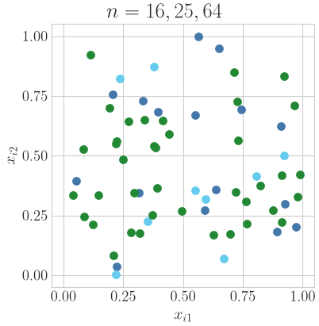

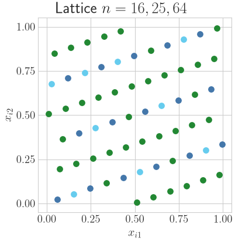

## Problem

### IID random sequences

- Extensible
  - Pause at any $n$ you like and add more points as needed
  - No problem if missing a few points here and there
- BUT slow convergence: $\Order(n^{-1/2})$

### Low discrepancy (LD) sequences

- Faster convergence: $\Order(n^{-1+\delta})$ for any $\delta > 0$
- BUT
  - Normally *not* easily extensible in $n$
    - Lattices [DKP22](https://doi.org/10.1007/978-3-031-09951-9): $n = 1, b, b^2, \ldots$
    - Digital nets DP10 : $n = 1, b, b^2, \ldots$
    - Halton [H60](https://doi.org/10.1007/BF01386213): $n = 1, 2, 3, \ldots$ but bad projections in higher dimensions
    - Kronecker [R51](https://scispace.com/pdf/the-evaluation-of-definite-integrals-and-a-quasi-monte-carlo-50ru8ixs80.pdf): $n = 1, 2, 3, \ldots$ less studied
  - *Not* robust to missing points

### Want LD sequences that are *extensible* in $n$ and *robust* to missing points

- Cannot have $\Order(n^{-p})$ convergence with $p > 1$ for all $n$
- Need new constructions, error bounds, and stopping criteria

## The sad and thrilling story of the missing $\vx_0$

### Some libraries/users drop $\vx_0 = (0,\ldots,0)$ in a LD sequence

- $(0,\ldots,0)$ looks too regular
- Transforming $\LDsim \Unif[0,1]^d$ to $\LDsim\Norm(\vzero,\mI)$ $0 \to -\infty$

The cure is to randomize the sequence, not to drop points

### This is a bad idea; should keep $\vx_0$ to

- Maintain balance that ensures low discrepancy
- Preserve the structure that allows for error bounds and stopping criteria, especially for Sobol’ and lattice sequences for $n = 1, b, b^2, \ldots$

The LD community urges users and libraries to keep $\vx_0$ in the sequence, [(SciPy, success)](https://docs.scipy.org/doc/scipy/reference/generated/scipy.stats.qmc.Sobol.html) and not to skip points [(MATLAB, not yet succeeded)](https://www.mathworks.com/help/stats/sobolset.html#btd9s8e-1)

But what if

- There is missing data, $f(\vx_{i_1}), f(\vx_{i_2}), \ldots, f(\vx_{i_{n_0}})$?
- We run out of budget before we reach the desired sample size?

# The best we can hope for

Building on [HKKN12](https://doi.org/10.1007/s11075-011-9482-5) we note that (see the proofs)

Suppose $\Dsc\bigl(\{\vx_i\}_{i=0}^{n_m-1}\bigr) \le C n_m^{-p}$ for a sequence of preferred sample sizes, $n_1, n_2, \ldots$:

- If $p > 1$, then $n_{m+1} - n_m$ cannot be bounded
- If you lose/gain a bounded number of *arbitrary* data, i.e., $n = n_m \pm n_0$, then $\Dsc\bigl(\{\vx_i\}_{i=0}^{n-1}\bigr) = \Order\bigl(n_m^{-\min(p,1)}\bigr)$
  - If $p \le 1$, then you do not lose any thing asymptotically
  - If $p > 1$, then you still have $\Order(n_m^{-1})$ convergence
- If you lose/gain a bounded proportion of data, $\alpha$, then $\Dsc\bigl(\{\vx_i\}_{i=0}^{n-1}\bigr) \lesssim \alpha$

# What we can do with lattice and Kronecker sequences

### Lattice sequences

$$\begin{align*}
\vx_i &= \phi_b(i) \vzeta + \vDelta \bmod \vone \\
\boldsymbol{\zeta} & \in \mathbb{N}^d, \quad \boldsymbol{\Delta} \in [0,1)^d\\
\phi_b\bigl((\cdots i_2 i_1 i_0)_{b} \bigr) & = {}_b0.i_0 i_1 i_2 \cdots \\
\phi_2(6) = \phi_2\bigl((110)_2\bigr) & = {}_20.011 = 0.375 = 3/8
\end{align*}$$

### Kronecker sequences

$$\begin{align*}
\vx_i &= i\boldsymbol{\zeta} + \boldsymbol{\Delta} \bmod \boldsymbol{1} \\
\boldsymbol{\zeta}, \boldsymbol{\Delta} & \in [0,1)^d\\
\end{align*}$$

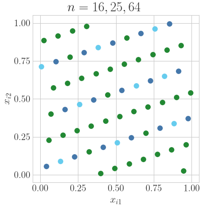

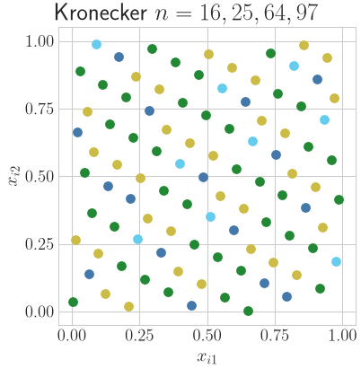

## Discrepancies and (weighted) expected squared discrepancies

$$\begin{align*}
\Dsc^2\bigl(\{\vx_i\}_{i=0}^{n-1}, \cf \bigr) &:= \sup_{\lVert f \rVert_{\cf} \le 1 }\left \lvert \int_{[0,1]^d} f(\vx) \, \dif \vx - \frac 1n \sum_{i=0}^{n-1} f(\vx_i) \right \rvert^2 \\
& =
\int_{[0,1]^d \times [0,1]^d} K(\vt, \vx) \, \dif \vt \dif \vx
- \frac{2}{n} \sum_{i=0}^{n-1} \int_{[0,1]^d} K(\vx_i, \vx) \, \dif \vx
+ \frac{1}{n^2} \sum_{i,j=0}^{n-1} K(\vx_i, \vx_j) \\
& \qquad \qquad \text{where } K \text{ is the reproducing kernel of the Hilbert space } \cf \ \href{https://arxiv.org/abs/2502.03644}{\text{HKS26}}
\end{align*}$$

$$\begin{gather*}
\ESD \bigl (\{\vx_i\}_{i=0}^{n-1}, \cf \bigr) := \Ex\left[ \Dsc^2\bigl (\{\vx_i + \vDelta \bmod \vone \}_{i=0}^{n-1}, \cf \bigr) \right] \\
\WESD (N,d) := \sum_{n=1}^N \alert{n} \, \ESD \bigl (\{\vx_i\}_{i=0}^{n-1}, \cf \bigr)
\end{gather*}$$

## (Weighted) expected squared discrepancies for lattice and Kronecker sequences

$$\begin{align*}
\textrm{ESD}\bigl (\{\phi_b(i) \vzeta \bmod \vone \}_{i=0}^{n-1} \ \class{alert}{\text{lattice}}, \cf \bigr)
& = - \overline{K} + \frac 1{n^2} \biggl [ n \tK(\boldsymbol{0}) + \sum_{k=1}^{b^{\lceil \log_b n\rceil}-1} \#_n(k) \tK\bigl( \phi_b(k) \boldsymbol{\zeta} \bmod \vone \bigr) \biggr] \\
\textrm{ESD}\bigl (\{i \vzeta \bmod \vone \}_{i=0}^{n-1}\ \class{alert}{\text{Kronecker}}, \cf \bigr)
& = - \overline{K} + \frac 1{n^2} \biggl [ n \tK(\boldsymbol{0}) + 2 \sum_{k=1}^{n -1}(n - k) \tK( k \boldsymbol{\zeta} \bmod \vone) \biggr] \\
\tK(\vx) &: = \int_{[0,1]^d} K(\vx + \vy \bmod \boldsymbol{1},
\vy) \, \dif \vy \qquad
\overline{K} : = \int_{[0,1]^d} \tK(\vx) \, \dif \vx\\
\#_n(k) &: = \mathrm{card}\bigl \{k : \phi_b(k) = \phi_b(i) - \phi_b(j) \bmod 1 \\
& \qquad \qquad \text{ s.t. } i, j, \in \{0, \ldots, n-1 \} \bigr\} \\
\WESD (N,d) & := \sum_{n=1}^N \alert{n} \, \ESD \left (\begin{Bmatrix} \{\phi_b(i) \vzeta \bmod \vone \}_{i=0}^{n-1} \text{ lattice} \\ \{i \vzeta \bmod \vone \}_{i=0}^{n-1} \text{ Kronecker} \end{Bmatrix}, \cf \right) \\
& \qquad \qquad \text{in } \alert{\Order(N)} \text{ operations}
\end{align*}$$

## Component-by-component (CBC) constructions for the generating vector $\vzeta$ assuming decaying coordinate weights $\gamma_\ell = \ell^{-2}$, $\ell=1, \ldots, d$

1. For $d=1$, choose $\zeta_1$ to minimize $\textrm{WSESD}(N, d)$
2. For $d = 2, \ldots, d_{\max}$, choose $\zeta_d$ to minimize $\textrm{WSESD} (N, d)$, given the previously chosen $\zeta_1, \ldots, \zeta_{d-1}$

Ours vs IID & CBC by [CKN06](https://doi.org/10.1137/06065074X)

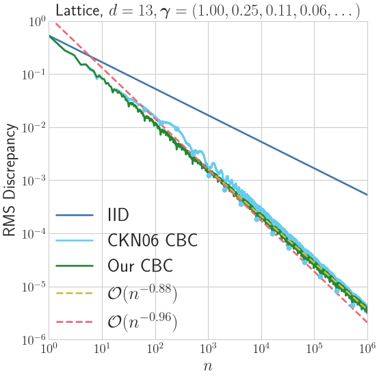

Ours vs IID, [R51](https://scispace.com/pdf/the-evaluation-of-definite-integrals-and-a-quasi-monte-carlo-50ru8ixs80.pdf), & DGLPS25

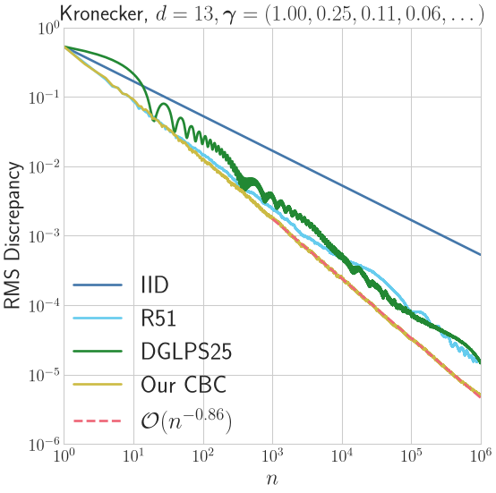

## Comparing lattice and Kronecker sequences

Comparing root mean squared discrepancies

$$\class{.alert}{\text{Keister}} \quad \int_{\reals^d} \cos(\lVert \vx \rVert) \, \exp(-\lVert \vx \rVert^2) \, \dif \vx = ?$$

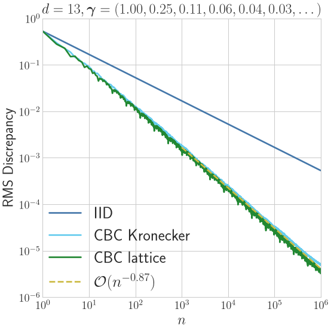

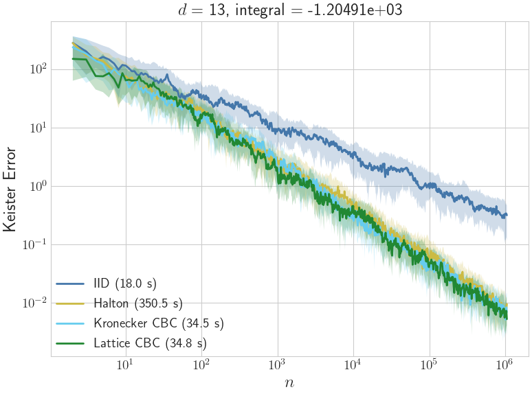

# Implementation

[`qmcpy`](https://qmcpy.org) is an open source Python library for quasi-Monte Carlo methods (develop branch has the *latest features*)

# Take-aways

### Conclusion

- Keep the preferred nodes, $\{\vx_i\}_{i=0}^{n_m}$, with best $n_m$ for optimal low discrepancy
- Don’t sweat it if you lose a few or have a few extra
  - If you really want higher order convergence, then use reproducing/covariance kernels to find optimal sample weights, but this takes work

### Further work

- More efficient CBC algorithms
- Theoretical guarantees for decay of discrepancy of Kronecker sequences by CBC
- Extend to digital sequences with arbitrary sample sizes
- Stopping rules based on
  - Decay of discrete Fourier coefficients of the integrand
  - Gaussian process surrogate models of the integrand

### Thank you!

# References

CKN06 R. Cools, F. Y. Kuo, & D. Nuyens, Constructing embedded lattice rules for multivariate integration, SIAM J. Sci. Comput. 28, 2162–2188 (2006). [DOI](https://doi.org/10.1137/06065074X) · [publisher](https://epubs.siam.org/doi/10.1137/06065074X)

DKP22 J. Dick, P. Kritzer, & F. Pillichshammer, Lattice Rules: Numerical Integration, Approximation, and Discrepancy. Springer Series in Computational Mathematics. Springer Cham (2022). [DOI](https://doi.org/10.1007/978-3-031-09951-9) · [publisher](https://link.springer.com/book/10.1007/978-3-031-09951-9)

DP10 J. Dick & F. Pillichshammer, Digital Nets and Sequences: Discrepancy Theory and Quasi-Monte Carlo Integration, Cambridge University Press (2010). [publisher](https://www.cambridge.org/core/books/digital-nets-and-sequences/9780521154566)

H60 J. Halton, On the Efficiency of Certain Quasi-Random Sequences of Points in Evaluating Multi-Dimensional Integrals, *Numer. Math.*, **2**, 84-90, (1960). [DOI](https://doi.org/10.1007/BF01386213) · [publisher](https://link.springer.com/article/10.1007/BF01386213)

HKS26 F. J. Hickernell, N. Kirk, & A. G. Sorokin, Quasi-Monte Carlo Methods: What, Why, and How?, in Monte Carlo and Quasi-Monte Carlo Methods: MCQMC, Waterloo, Canada, August 2024, (eds. C. Lemieux and B. Feng), pp. 3–40, 2026. [arXiv](https://arxiv.org/abs/2502.03644)

## References (cont’d)

HKKN12 F. J. Hickernell, P. Kritzer, P. Kuo, & D. Nuyens, Weighted compound integration rules with higher order convergence for all $N$. *Numer. Algor.* **59**, 161–183 (2012). [DOI](https://doi.org/10.1007/s11075-011-9482-5) ·  
[publisher](https://link.springer.com/article/10.1007/s11075-011-9482-5)

R51 R. D. Richtmyer, The Evaluation of Definite Integrals, and a Quasi-Monte-Carlo Method Based on the Properties of Algebraic Numbers, Los Alamos Scientific Laboratory, LA-1342 (1951). [report](https://scispace.com/pdf/the-evaluation-of-definite-integrals-and-a-quasi-monte-carlo-50ru8ixs80.pdf) · *(see [Wikipedia](https://en.wikipedia.org/wiki/Robert_D._Richtmyer))*

# Proofs

For a fixed Banach space of integrands, $\cf$, we have bounds on the discrepancy of any $n$-point set, $\{\vt_i\}_{i=0}^{n-1}$:

$$0 < a n^{-Q} \le \inf_{\{\vt_i\}_{i=0}^{n-1} \subset [0,1]^d} \Dsc\bigl(\{\vt_i\}_{i=0}^{n-1}\bigr) \le \sup _{\{\vt_i\}_{i=0}^{n-1} \subset [0,1]^d} \Dsc\bigl(\{\vt_i\}_{i=0}^{n-1}\bigr)\le A, \qquad n = 1, 2, \ldots$$

And also that for a specific sequence of nodes, $\{\vx_i\}_{i=0}^{\infty}$ and a sequence of sample sizes, $1 \le n_1 < n_2 < \ldots$, we have better bounds on the discrepancy:

$$c n_m^{-P} \le \Dsc\bigl(\{\vx_i\}_{i=0}^{n_m-1}\bigr) \le C n_m^{-p} \qquad k = 1, 2, \ldots$$

where $0 \le p \le P \le Q$.

Note that for all $n_- < n_+ = n_-+n_0$, we have

$$\begin{multline*}
n_+ \left ( \int_{[0,1]^d} f(\vx) \, \dif \vx - \frac{1}{n_+} \sum_{i=0}^{n_+-1} f(\vx_i) \right) \\
= n_- \left ( \int_{[0,1]^d} f(\vx) \, \dif \vx - \frac{1}{n_-} \sum_{i=0}^{n_--1} f(\vx_i) \right) + n_0 \left ( \int_{[0,1]^d} f(\vx) \, \dif \vx - \frac{1}{n_0} \sum_{i=n_-}^{n_+-1} f(\vx_i) \right)
\end{multline*}$$

which implies that

$$\begin{align*}
\Dsc\bigl(\{\vx_i\}_{i=0}^{n_+-1}\bigr) &
\le \frac{n_-}{n_+} \Dsc\bigl(\{\vx_i\}_{i=0}^{n_--1}\bigr) +\frac{n_0}{n_+} \Dsc\bigl(\{\vx_i\}_{i=n_-}^{n_+-1}\bigr)
\\
\Dsc\bigl(\{\vx_i\}_{i=0}^{n_--1}\bigr) &
\le \frac{n_+}{n_-} \Dsc\bigl(\{\vx_i\}_{i=0}^{n_+-1}\bigr) + \frac{n_0}{n_-} \Dsc\bigl(\{\vx_i\}_{i=n_-}^{n_+-1}\bigr)
\\
\Dsc\bigl(\{\vx_i\}_{i=n_-}^{n_+-1}\bigr) &
\le \frac{n_+}{n_0} \Dsc\bigl(\{\vx_i\}_{i=0}^{n_+-1}\bigr) + \frac{n_-}{n_0} \Dsc\bigl(\{\vx_i\}_{i=0}^{n_--1}\bigr)
\end{align*}$$

## $n_{m+1} - n_m$ must grow if $p > 1$

If $n_- = n_{m}$, $n_+ = n_{m+1}$, and $n_0 = n_{m+1} - n_m$, then

$$\begin{align*}
0 < a (n_{m+1} - n_m) ^{-Q} & \le \Dsc\bigl(\{\vx_i\}_{i=n_m}^{n_{m+1}-1}\bigr) \\
& \le \frac{n_{m+1}}{n_{m+1} - n_m} \Dsc\bigl(\{\vx_i\}_{i=0}^{n_{m+1}-1}\bigr) + \frac{n_m}{n_{m+1} - n_m} \Dsc\bigl(\{\vx_i\}_{i=0}^{n_{m}-1}\bigr) \\
& \le (n_{m+1} - n_m)^{-1} C (n_{m+1}^{1-p} + n_m^{1-p}) \\
a &\le C (n_{m+1} - n_m)^{Q-1} (n_{m+1}^{1-p} + n_m^{1-p}) \\
\end{align*}$$

So if $1 < p <Q$, then $n_{m+1} - n_m$ must grow at least on the order of $n_m^{\frac{p-1}{Q-1}}$

## $\Order\bigl(n_m^{-\min(p,1)}\bigr)$ discrepancy if we lose/gain a bounded number of data

### Losing points

If $n_{+} = n_m$, and $n_- = n_m - n_0$ then

$$\begin{align*}
\Dsc\bigl(\{\vx_i\}_{i=n_0}^{n_{m} -n_0 -1}\bigr)
& \le \frac{n_{m}}{n_{m} - n_0} \Dsc\bigl(\{\vx_i\}_{i=0}^{n_{m}-1}\bigr) + \frac{n_0}{n_{m} - n_0} \Dsc\bigl(\{\vx_i\}_{i=n_m - n_0}^{n_m-1}\bigr) \\
& \le \frac{C n_{m}^{-p} + An_0 n_m^{-1}}{1 - n_0/n_m}
\end{align*}$$

### Gaining points

If $n_{-} = n_m$, and $n_+ = n_m +n_0$ then

$$\begin{align*}
\Dsc\bigl(\{\vx_i\}_{i=n_0}^{n_{m} + n_0 -1}\bigr)
& \le \frac{n_{m}}{n_{m} + n_0} \Dsc\bigl(\{\vx_i\}_{i=0}^{n_{m}-1}\bigr) + \frac{n_0}{n_{m} + n_0} \Dsc\bigl(\{\vx_i\}_{i=n_m}^{n_m+n_0-1}\bigr) \\
& \le \frac{C n_{m}^{-p} + An_0 n_m^{-1}}{1 + n_0/n_m}
\end{align*}$$

In both cases,

- If $n_0$ is bounded, then the discrepancy decays as $\Order(n_m^{-\min(p,1)})$ as $k\to\infty$
- If instead $n_0 \le \alpha n_m$, then the discrepancy is no worse than proportional to $\alpha$, i.e. $\Dsc\bigl(\{\vx_i\}_{i=0}^{n-1}\bigr) \lesssim \alpha$

Back to the best we can hope for